# Clustering Samples

19 March 2019

Filter criteria:

- Filter differentially expressed genes between autism and control (**adjusted** p-value < 0.05)
- No samples are removed based on network connectivity z-scores

```r
glue('Number of genes: ', nrow(datExpr), '\n',
     'Number of samples: ', ncol(datExpr), ' (', sum(datMeta$Diagnosis_=='ASD'), ' ASD, ',
     sum(datMeta$Diagnosis_!='ASD'), ' controls)')
```

```
## Number of genes: 3385
## Number of samples: 86 (51 ASD, 35 controls)
```

### Dimensionality reduction using PCA

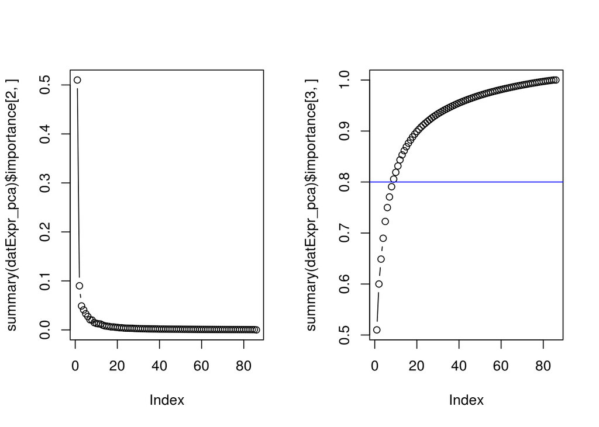

[output not shown]

```r
reduce_dim_datExpr = function(datExpr, datMeta, var_explained=0.8, filter_controls=FALSE){

  datExpr = data.frame(datExpr)

  if(filter_controls){
    datMeta = datMeta %>% filter(Diagnosis_=='ASD')
    datExpr = datExpr %>% select(paste0('X', datMeta_ASD$Dissected_Sample_ID))
  }

  datExpr_pca = prcomp(t(datExpr), scale=TRUE)
  par(mfrow=c(1,2))
  plot(summary(datExpr_pca)$importance[2,], type='b')
  plot(summary(datExpr_pca)$importance[3,], type='b')
  abline(h=var_explained, col='blue')

  last_pc = data.frame(summary(datExpr_pca)$importance[3,]) %>% rownames_to_column(var='ID') %>%
    filter(.[[2]] >= var_explained) %>% top_n(-1, ID)

  print(glue('Keeping top ', substr(last_pc$ID, 3, nchar(last_pc$ID)), ' components that explain ',
             var_explained*100, '% of the variance'))

  datExpr_top_pc = datExpr_pca$x %>% data.frame %>% dplyr::select(PC1:last_pc$ID)

  return(list('datExpr'=datExpr_top_pc, 'datMeta'=datMeta, 'pca_output'=datExpr_pca))
}

reduce_dim_output = reduce_dim_datExpr(datExpr, datMeta)
```

```r
datExpr_redDim = reduce_dim_output$datExpr
datMeta_redDim = reduce_dim_output$datMeta
pca_output = reduce_dim_output$pca_output

rm(datSeq, datProbes, reduce_dim_datExpr, reduce_dim_output, datExpr, datMeta)
```

### Clustering

```r
clusterings = list()
```

#### K-means Clustering

No recognisable best k, so chose k=5

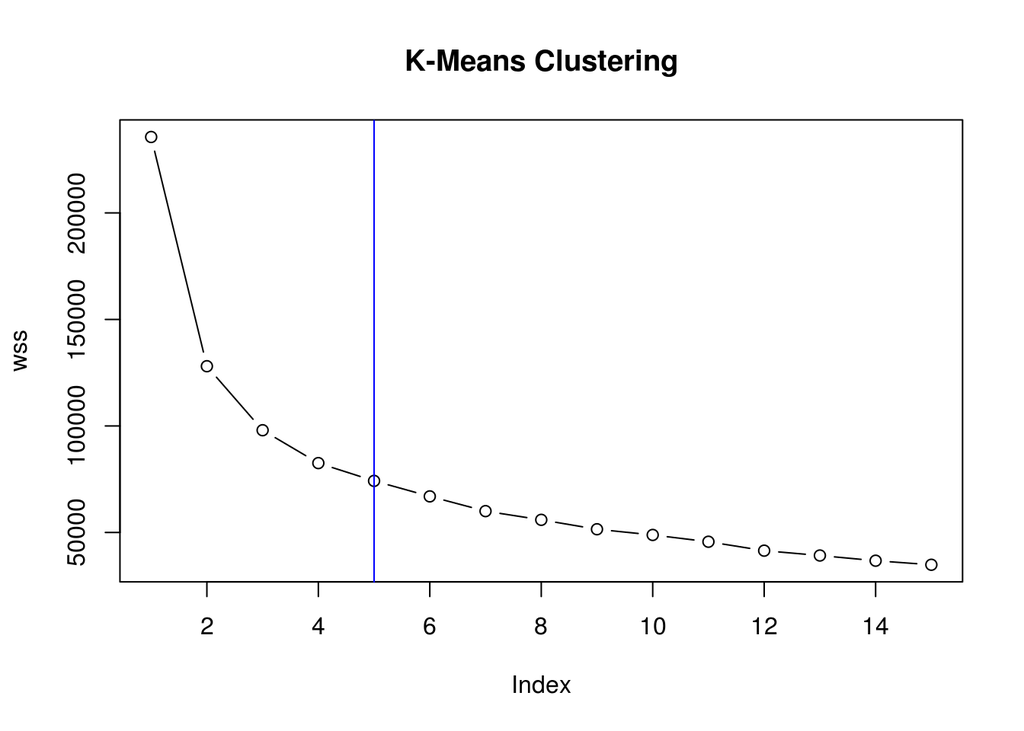

```r
set.seed(123)
wss = sapply(1:15, function(k) kmeans(datExpr_redDim, k, nstart=25)$tot.withinss)
plot(wss, type='b', main='K-Means Clustering')
best_k = 5
abline(v = best_k, col='blue')
```

```r
datExpr_k_means = kmeans(datExpr_redDim, best_k, nstart=25)
clusterings[['km']] = datExpr_k_means$cluster
```

#### Hierarchical Clustering

Chose k=7 as best number of clusters.

Younger ASD samples seem to be more similar to control samples than older ASD samples (pink cluster has most of the youngest samples). The yellow cluster is made of young ASD samples. Most old ASD samples are also close together.

Colors:

- Diagnosis: Blue=control, Green=ASD
- Sex: Pink=Female, Blue=Male
- Brain region: Pink=Frontal, Green=Temporal, Blue=Parietal, Purple=Occipital
- Age: Purple=youngest, Yellow=oldest

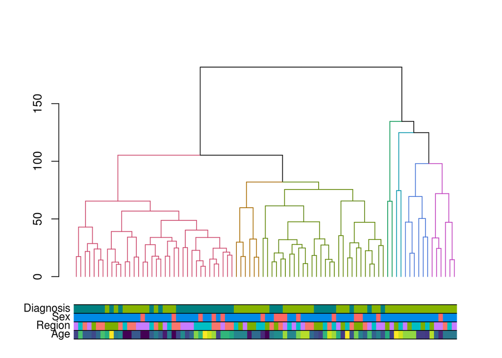

```r
h_clusts = datExpr_redDim %>% dist %>% hclust %>% as.dendrogram
# h_clusts %>% plot
best_k = 7
clusterings[['hc']] = cutree(h_clusts, best_k)

create_viridis_dict = function(age){
  min_age = datMeta_redDim$Age %>% min
  max_age = datMeta_redDim$Age %>% max
  viridis_age_cols = viridis(max_age - min_age + 1)
  names(viridis_age_cols) = seq(min_age, max_age)

  return(viridis_age_cols)
}
viridis_age_cols = create_viridis_dict()

dend_meta = datMeta_redDim[match(gsub('X','',labels(h_clusts)), rownames(datMeta_redDim)),] %>%
            mutate('Diagnosis' = ifelse(Diagnosis_=='CTL','#008080','#86b300'), # Blue control, Green ASD
                   'Sex' = ifelse(Sex=='F','#ff6666','#008ae6'),                # Pink Female, Blue Male
                   'Region' = case_when(Brain_lobe=='Frontal'~'#F8766D',        # ggplot defaults for 4 colours
                                      Brain_lobe=='Temporal'~'#7CAE00',
                                      Brain_lobe=='Parietal'~'#00BFC4',
                                      Brain_lobe=='Occipital'~'#C77CFF'),
                   'Age' = viridis_age_cols[as.character(Age)]) %>%            # Purple: young, Yellow: old
            dplyr::select(Age, Region, Sex, Diagnosis)
h_clusts %>% set('labels', rep('', nrow(datMeta_redDim))) %>% set('branches_k_color', k=best_k) %>% plot
colored_bars(colors=dend_meta)
```

#### Consensus Clustering

Samples are grouped into two big clusters and a small third cluster with 5 samples, and then the two big clusters have 5 and 8, respectively.

*Output plots in clustering_samples_03_15 folder

#### Independent Component Analysis

Following this paper’s guidelines:

0. Run PCA and keep enough components to explain 60% of the variance
1. Run ICA with that same number of nbComp as principal components kept to then filter them
2. Select components with kurtosis > 3
3. Assign obs to genes with FDR<0.001 using the fdrtool package

[output not shown]

Not a good method for clustering samples because:

1. ICA does not perform well with small samples (see [Figure 4](https://www.nature.com/articles/s41467-018-03424-4/figures/4) of [this paper](https://www.nature.com/articles/s41467-018-03424-4))
2. Warnings: (Warning in fdrtool(x, plot = F): There may be too few input test statistics for reliable FDR calculations!)
3. Leaves most of the observations (55) without a cluster:

```r
ICA_clusters %>% rowSums %>% table
```

```
## .
##  0  1  2  3
## 55 25  5  1
```

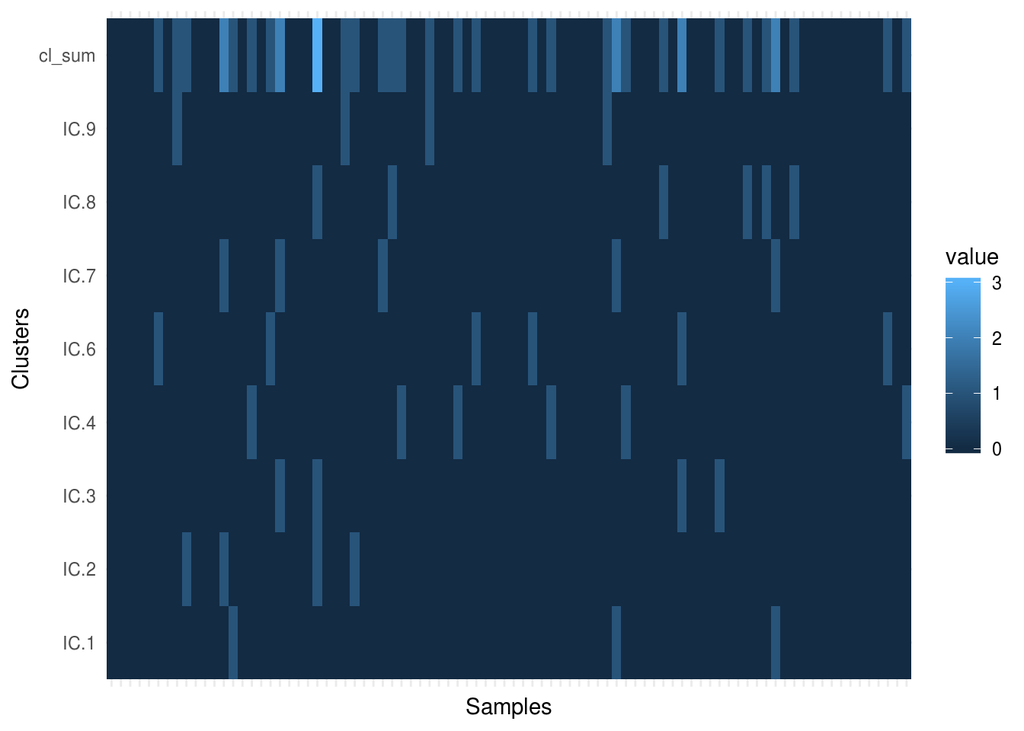

```r
ICA_clusters %>% mutate(cl_sum=rowSums(.)) %>% as.matrix %>% melt %>% ggplot(aes(Var2,Var1)) +
  geom_tile(aes(fill=value)) + xlab('Clusters') + ylab('Samples') +
  theme_minimal() + theme(axis.text.x=element_blank(), axis.ticks.x=element_blank()) + coord_flip()
```

#### WGCNA

```r
best_power = datExpr_redDim %>% t %>% pickSoftThreshold(powerVector = seq(10, 30, by=1))
```

```
##    Power SFT.R.sq  slope truncated.R.sq mean.k. median.k. max.k.
## 1     10    0.665 -0.610          0.619   4.300     3.230  12.70
## 2     11    0.648 -0.658          0.599   3.700     2.620  11.40
## 3     12    0.634 -0.749          0.621   3.210     2.130  10.30
## 4     13    0.587 -0.816          0.529   2.810     1.850   9.33
## 5     14    0.762 -0.817          0.767   2.470     1.620   8.52
## 6     15    0.786 -0.820          0.806   2.200     1.410   7.82
## 7     16    0.801 -0.825          0.817   1.960     1.220   7.21
## 8     17    0.823 -0.833          0.836   1.760     1.060   6.67
## 9     18    0.830 -0.883          0.825   1.590     0.932   6.19
## 10    19    0.833 -0.902          0.842   1.440     0.834   5.77
## 11    20    0.797 -0.901          0.775   1.310     0.753   5.39
## 12    21    0.873 -0.919          0.900   1.200     0.686   5.05
## 13    22    0.812 -0.924          0.794   1.100     0.616   4.74
## 14    23    0.843 -0.929          0.833   1.010     0.565   4.47
## 15    24    0.862 -0.943          0.862   0.933     0.528   4.22
## 16    25    0.864 -0.933          0.868   0.863     0.485   3.99
## 17    26    0.872 -0.952          0.862   0.801     0.444   3.78
## 18    27    0.866 -0.938          0.851   0.745     0.407   3.59
## 19    28    0.880 -0.928          0.874   0.695     0.374   3.41
## 20    29    0.819 -0.936          0.779   0.649     0.349   3.25
## 21    30    0.819 -0.911          0.778   0.608     0.320   3.10
```

```r
network = datExpr_redDim %>% t %>% blockwiseModules(power=best_power$powerEstimate, numericLabels=TRUE)
```

```
##      mergeCloseModules: less than two proper modules.
##       ..color levels are 0, 1
##       ..there is nothing to merge.
```

```r
clusterings[['WGCNA']] = network$colors
names(clusterings[['WGCNA']]) = rownames(datExpr_redDim)
```

It finds a single cluster grouping 60 observations and leaves the rest without cluster:

```r
table(clusterings[['WGCNA']])
```

```
##
##  0  1
## 26 60
```

#### Gaussian Mixture Models with hard thresholding

Points don’t seem to follow a Gaussian distribution no matter the number of clusters, chose 5 points following the best k from K-means because the methods are similar

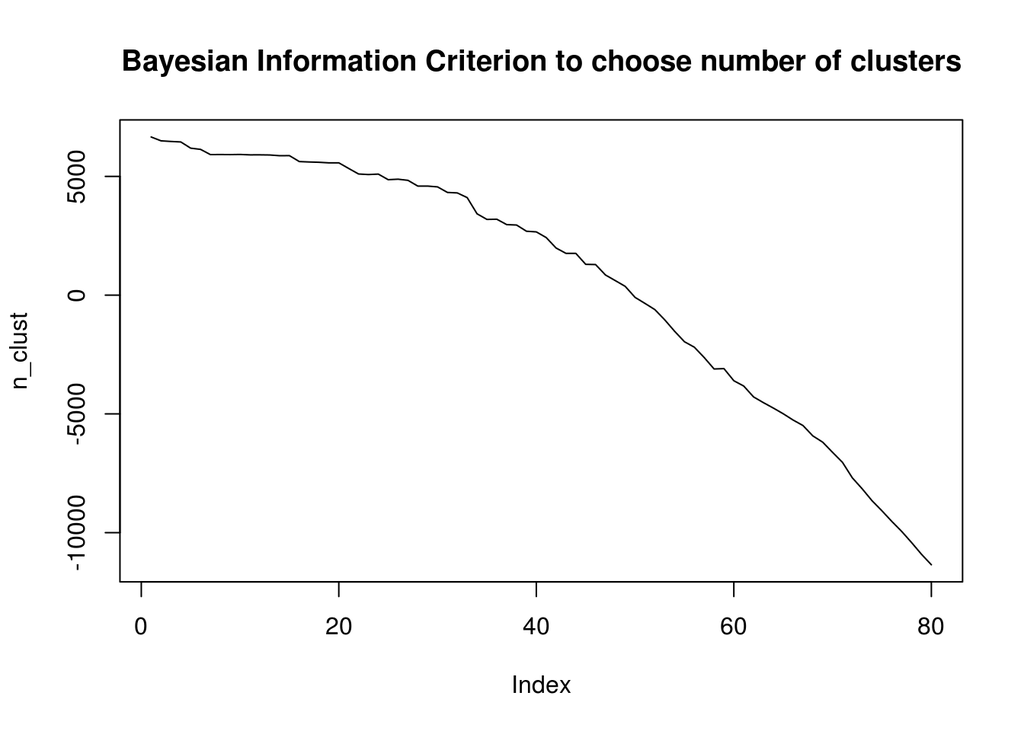

```r
n_clust = datExpr_redDim %>% Optimal_Clusters_GMM(max_clusters=80, criterion='BIC', plot_data=FALSE)
plot(n_clust, type='l', main='Bayesian Information Criterion to choose number of clusters')
```

```r
best_k = 5 # copying k-means best_k
gmm = datExpr_redDim %>% GMM(best_k)
clusterings[['GMM']] = gmm$Log_likelihood %>% apply(1, which.max)
```

Plot of clusters with their centroids in gray

```r
gmm_points = rbind(datExpr_redDim, setNames(data.frame(gmm$centroids), names(datExpr_redDim)))
gmm_labels = c(clusterings[['GMM']], rep(NA, best_k)) %>% as.factor
ggplotly(gmm_points %>% ggplot(aes(x=PC1, y=PC2, color=gmm_labels)) + geom_point() + theme_minimal())
```

[interactive chart not shown]

```r
rm(wss, datExpr_k_means, h_clusts, cc_output, cc_output_c1, cc_output_c2, best_k, ICA_output,
   ICA_clusters_names, signals_w_kurtosis, n_clust, gmm, gmm_points, gmm_labels, network, dend_meta,
   best_power, c, viridis_age_cols, create_viridis_dict)
```

### Compare clusterings

Using Adjusted Rand Index:

- All clusterings are pretty similar except for WGCNA and ICA
- GMM CC_l1 are the most similar
- ICA seems to be clustering individuals together, but not as much as last time
- CC_l1 is the one with the strongest relation to ASD

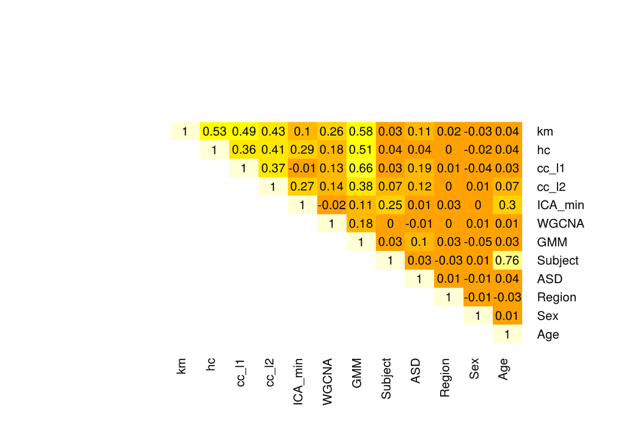

```r
clusters_plus_phenotype = clusterings
clusters_plus_phenotype[['Subject']] = datMeta_redDim$Subject_ID
clusters_plus_phenotype[['ASD']] = datMeta_redDim$Diagnosis_
clusters_plus_phenotype[['Region']] = datMeta_redDim$Brain_lobe
clusters_plus_phenotype[['Sex']] = datMeta_redDim$Sex
clusters_plus_phenotype[['Age']] = datMeta_redDim$Age

cluster_sim = data.frame(matrix(nrow = length(clusters_plus_phenotype), ncol = length(clusters_plus_phenotype)))
for(i in 1:(length(clusters_plus_phenotype))){
  cluster1 = as.factor(clusters_plus_phenotype[[i]])
  for(j in (i):length(clusters_plus_phenotype)){
    cluster2 = as.factor(clusters_plus_phenotype[[j]])
    cluster_sim[i,j] = adj.rand.index(cluster1, cluster2)
  }
}
colnames(cluster_sim) = names(clusters_plus_phenotype)
rownames(cluster_sim) = colnames(cluster_sim)

cluster_sim = cluster_sim %>% as.matrix %>% round(2)
heatmap.2(x = cluster_sim, Rowv = FALSE, Colv = FALSE, dendrogram = 'none',
          cellnote = cluster_sim, notecol = 'black', trace = 'none', key = FALSE,
          cexRow = 1, cexCol = 1, margins = c(7,7))
```

```r
rm(i, j, cluster1, cluster2, clusters_plus_phenotype, cluster_sim)
```

### Scatter plots

```r
create_2D_plot = function(cat_var){
 ggplotly(plot_points %>% ggplot(aes_string(x='PC1', y='PC2', color=cat_var)) +
          geom_point() + theme_minimal() +
          xlab(paste0('PC1 (', round(summary(pca_output)$importance[2,1]*100,2),'%)')) +
          ylab(paste0('PC2 (', round(summary(pca_output)$importance[2,2]*100,2),'%)')))
}
create_3D_plot = function(cat_var){
  plot_points %>% plot_ly(x=~PC1, y=~PC2, z=~PC3) %>% add_markers(color=plot_points[,cat_var], size=1) %>%
    layout(title = glue('Samples coloured by ', cat_var),
           scene = list(xaxis=list(title=glue('PC1 (',round(summary(pca_output)$importance[2,1]*100,2),'%)')),
                        yaxis=list(title=glue('PC2 (',round(summary(pca_output)$importance[2,2]*100,2),'%)')),
                        zaxis=list(title=glue('PC3 (',round(summary(pca_output)$importance[2,3]*100,2),'%)'))))
}

plot_points = datExpr_redDim %>% data.frame() %>% dplyr::select(PC1:PC3) %>%
              mutate(ID = rownames(.), subject_ID = datMeta_redDim$Subject_ID,
                km_clust = as.factor(clusterings[['km']]),       hc_clust = as.factor(clusterings[['hc']]),
                cc_l1_clust = as.factor(clusterings[['cc_l1']]), cc_clust = as.factor(clusterings[['cc_l2']]),
                ica_clust = as.factor(clusterings[['ICA_min']]), n_ica_clust = as.factor(rowSums(ICA_clusters)),
                gmm_clust = as.factor(clusterings[['GMM']]),     wgcna_clust = as.factor(clusterings[['WGCNA']]),
                sex = as.factor(datMeta_redDim$Sex),             region = as.factor(datMeta_redDim$Brain_lobe),
                diagnosis = as.factor(datMeta_redDim$Diagnosis_), age = datMeta_redDim$Age)
```

#### 2D plots of clusterings

```r
create_2D_plot('km_clust')
```

[interactive chart not shown]

```r
create_2D_plot('hc_clust')
```

[interactive chart not shown]

```r
create_2D_plot('cc_l1_clust')
```

[interactive chart not shown]

```r
create_2D_plot('cc_clust')
```

[interactive chart not shown]

```r
create_2D_plot('ica_clust')
```

[interactive chart not shown]

```r
create_2D_plot('gmm_clust')
```

[interactive chart not shown]

```r
create_2D_plot('wgcna_clust')
```

[interactive chart not shown]

#### 2D plots of Phenotypes

```r
create_2D_plot('diagnosis')
```

[interactive chart not shown]

```r
create_2D_plot('region')
```

[interactive chart not shown]

```r
create_2D_plot('sex')
```

[interactive chart not shown]

```r
create_2D_plot('age')
```

[interactive chart not shown]

3D plots

```r
create_3D_plot('ica_clust')
```

[interactive chart not shown]

```r
create_3D_plot('wgcna_clust')
```

[interactive chart not shown]